# Hydrographs

```r
library(HydroBOT)
library(ggplot2)
library(dplyr)
```

# Overview

This notebook provides descriptive plots of the inputs to HydroBOT (hydrographs), as they are often necessary for understanding the outputs. It also shows how `plot_outcomes()` is not restricted only to module outcomes, but is instead flexible enough to use nearly any dataframe with quantitative values. Though we plot the hydrographs here, this is the same approach as any other line plot. Though these are plots of the inputs, they do still allow various sorts of comparisons, whether simple visual comparisons or calculated differences, relative flows, etc.

## Demonstration setup

As usual, we need paths to the data, in this case the hydrographs.

```r
project_dir <- file.path("more_scenarios")
hydro_dir <- file.path(project_dir, "hydrographs")
```

Get scenario metadata.

```r
scenarios <- yaml::read_yaml(file.path(hydro_dir, "scenario_metadata.yml")) |>
  tibble::as_tibble()
```

We have a lot of hydrographs, so for this demonstration, we will often use a subset of gauges and scenarios.

```r
gauges_to_plot <- c("412002", "419001", "422028", "421001")
scenarios_to_plot <- c("climatedown2adapt0", "climatebaseadapt0", "climateup2adapt0")

scenarios <- scenarios |>
  filter(scenario %in% scenarios_to_plot)
```

# Standard scenario appearance

We will typically have a consistent look for the scenarios across the project, with a logical ordering and standard colours. Such standard colours are not included in the {HydroBOT} package because they are project/analysis- specific, but they could be set at project-level, e.g. in the `.Rprofile`, if desired.

Here, we use the special arguments `refvals` and `refcols` to make a colour palette from a standard {paletter} option (“ggsci::nrc_npg”) while setting a specific level to a specified value. We will use the codes (see scenario definitions) rather than the names to make plots readable.

```r
sceneorder <- forcats::fct_reorder(
  scenarios$scenario,
  scenarios$flow_multiplier
)

scene_pal <- make_pal(unique(scenarios$climate_code),
  palette = "ggsci::nrc_npg",
  refvals = "E", refcols = "black"
)

scene_pal
```

```
<colors>
black #E64B35FF #4DBBD5FF
```

We will also make a standard set of gauge colours

```r
gauge_pal <- make_pal(unique(gauges_to_plot),
  palette = "nationalparkcolors::Denali"
)
gauge_pal
```

```
<colors>
#73979DFF #DADCD7FF #43200EFF #E16509FF
```

# Plotting hydrographs

We first read in the hydrographs, with a bit of standardised data processing. The `read_hydro` function knows about the standard data organisation format, and so pulls hydrographs from all scenarios. The hydrographs are typically daily and so large. For simplicity here, we use the `scenariofilter` argument (which just does a regex on the filenames) to select a subset.

```r
scenehydros <- read_hydro(hydro_dir,
  long = TRUE, format = "csv",
  scenariofilter = scenarios_to_plot
)

scenehydros <- scenehydros |>
  # these have EWR-specific _flow after the gauge name
  mutate(gauge = stringr::str_remove_all(gauge, "_[a-z]*")) |>
  # because gauges are not their own files, we have to filter them on read-in
  filter(gauge %in% gauges_to_plot) |>
  left_join(scenarios)
```

Now, we can make a simple plot using the standard format and colours

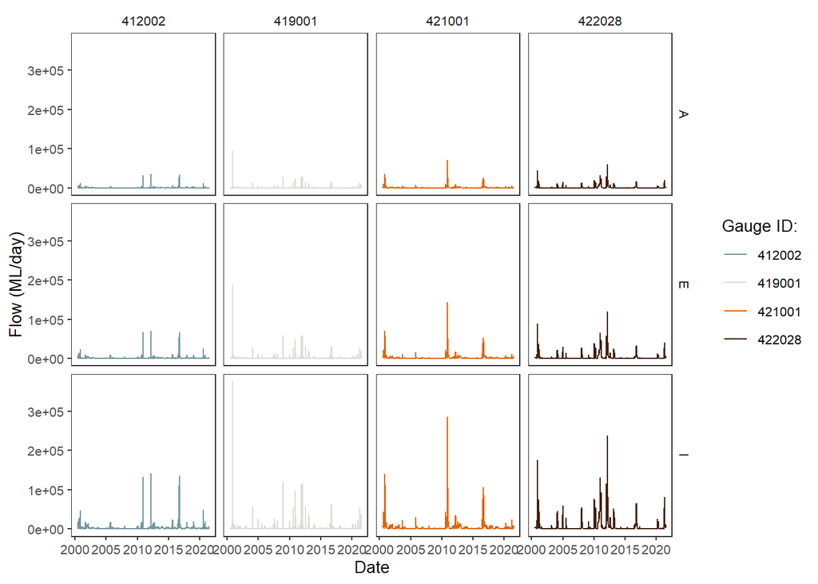

```r
plot_outcomes(scenehydros,
  outcome_col = "flow",
  outcome_lab = "Flow (ML/day)",
  x_col = "Date",
  colorset = "gauge",
  color_lab = "Gauge ID:",
  pal_list = gauge_pal,
  facet_row = "climate_code",
  facet_col = "gauge",
)
```

We can access the `scales` argument from `ggplot2::facet_*` and `trans` arguments of of `ggplot2::scale_y_continuous` if we want to change the look.

[figure not shown]

```r
plot_outcomes(scenehydros,
  outcome_col = "flow",
  outcome_lab = "Flow (ML/day)",
  x_col = "Date",
  colorset = "gauge",
  color_lab = "Gauge ID:",
  pal_list = gauge_pal,
  facet_row = "climate_code",
  facet_col = "gauge",
  transy = "log10",
  scales = "free_y"
)
```

# Baselining

All plotting functions provide the ability to set a base level and calculate changes in the other levels. First, we’ll show how that works under the hood, and then the more usual way directly in the `plot_outcomes()` call.

## How it works

The baseline can be either a scenario name or a scalar. We could potentially use something else like historical daily means, but that is not currently implemented, largely because it hasn’t yet been necessary- one of the scenarios is almost always an obvious baseline.

Internally, the `plot_outcome()` function calls `baseline_compare()`, but `baseline_compare()` can be used externally as well (and is actually quite useful in a number of places to baseline long data).

For example, we might want to calculate the difference between the modified scenarios and the `base` scenario. To do this, we simply pass in the data, the columns defining the groups `compare_col`, and the `base_lev`, that is, the value in `compare_col` that is the baseline situation. We also need to tell it which column contains the values, and the function `comp_fun` we want to use for the comparison. Here, we ask for the `difference` to the baseline provided by the base scenario.

In short, this gets the difference of the 0.5x and 2x scenario compared to the historical. We use difference here because these are simple multiplicative scenarios, and so the `relative` comparison would be trivially 0.5 or 2. In general, though, relative change is often more appropriate.

```r
dif_flow <- baseline_compare(scenehydros,
  compare_col = "scenario",
  base_lev = "climatebaseadapt0",
  values_col = "flow",
  comp_fun = difference,
  group_cols = c("Date", "gauge")
)
```

Now we can feed the dif_flow dataframe to `plot_outcomes()` directly. We see that, as expected, `base` is now a flat line at 0, while the 2x and 0.5x go up and down, respectively.

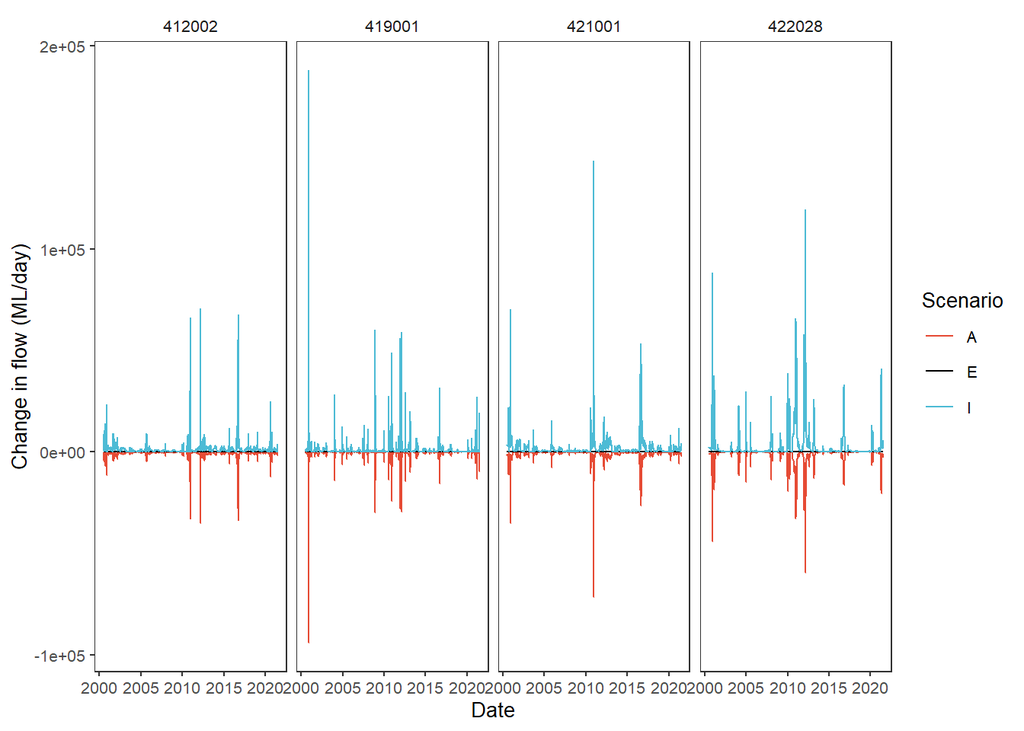

```r
plot_outcomes(dif_flow,
  outcome_col = "difference_flow",
  outcome_lab = "Change in flow (ML/day)",
  x_col = "Date",
  colorset = "climate_code",
  color_lab = "Scenario",
  pal_list = scene_pal,
  # facet_row = 'climate_code',
  facet_col = "gauge"
)
```

## Internal to plot_outcomes()

In practice, we would typically let the baselining happen internally to the `plot_outcomes()` function so we aren’t carrying around and keeping track of a bunch of altered dataframes. To replicate the above plot, we only have to feed `plot_outcomes()` the `base_lev` and `comp_fun` arguments in `base_list`. If we want to do something more unusual with the baselining, we will need to do it externally. We can though specify a custom function of x and y, here the *extremely* contrived `sqrtdif`.

**Note**

We would get a warning here about not being explicit about the `group_cols` argument to the baselining function if it were not included, which just groups by everything non-numeric if that argument is not given.

This automatically labels with a long but meaningful name.

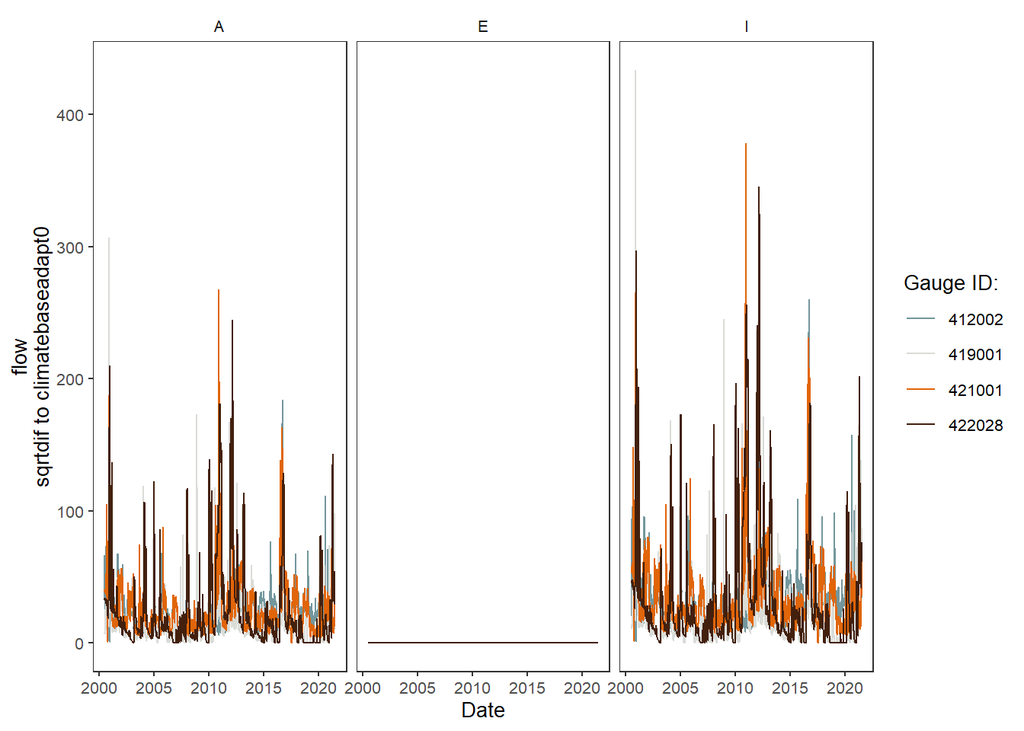

```r
sqrtdif <- function(x, y) {
  sqrt(abs(x - y))
}

plot_outcomes(scenehydros,
  outcome_col = "flow",
  x_col = "Date",
  colorset = "gauge",
  color_lab = "Gauge ID:",
  pal_list = gauge_pal,
  base_list = list(
    base_lev = "climatebaseadapt0",
    values_col = "flow",
    comp_fun = "sqrtdif",
    group_cols = c("Date", "gauge")
  ),
  facet_col = "climate_code"
)
```

One way this could be very useful is for lagged or windowed operations, which we do here very simply by getting the difference to the baseline one day previous. The use in practice would need to be developed carefully to address specific questions.

```r
lagdif <- function(x, y) {
  x - lag(y)
}
```

We can change the `outcome_lab` as well, though to make sure information isn’t lost, the baselining is appended.

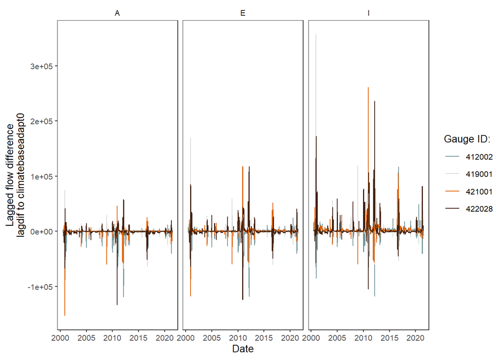

```r
lagplot <- plot_outcomes(scenehydros,
  outcome_col = "flow",
  outcome_lab = "Lagged flow difference",
  x_col = "Date",
  colorset = "gauge",
  color_lab = "Gauge ID:",
  pal_list = gauge_pal,
  base_list = list(
    base_lev = "climatebaseadapt0",
    values_col = "flow",
    comp_fun = "lagdif",
    group_cols = c("Date", "gauge")
  ),
  facet_col = "climate_code"
)

lagplot
```

Because this is a ggplot object, we can change that y-label if we really don’t want the explanation.

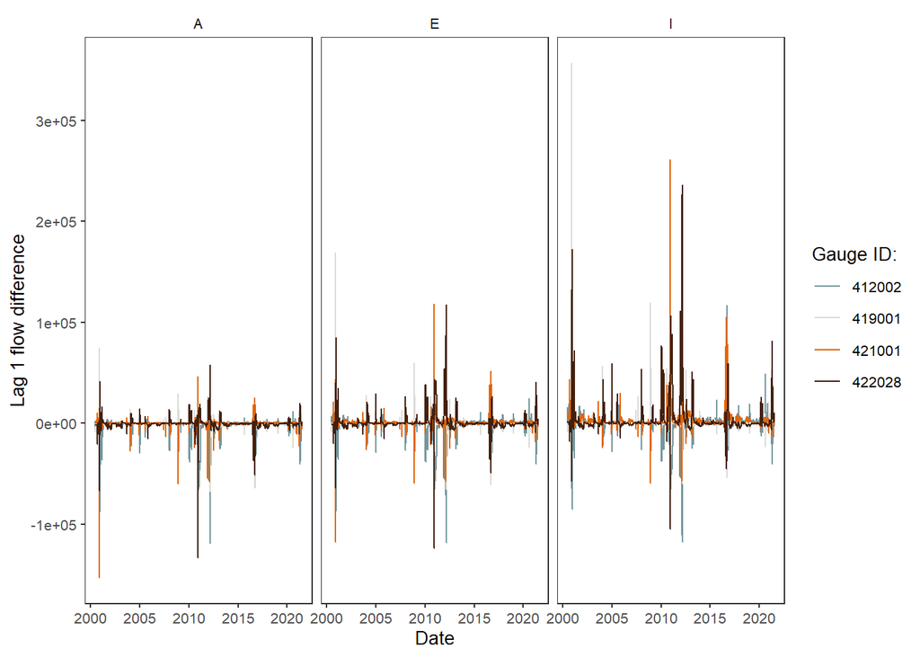

```r
lagplot + labs(y = "Lag 1 flow difference")
```

## Netcdfs

Briefly, the `read_hydro()` function can also read `.nc` files, but is a bit more constrained as to their format. As a quick demonstration with the data provided with HydroBOT, we can read them in and plot.

```r
nchydros <- read_hydro(system.file("extdata/ncdfexample/nchydros", package = "HydroBOT"),
  long = TRUE, format = "nc"
)
```

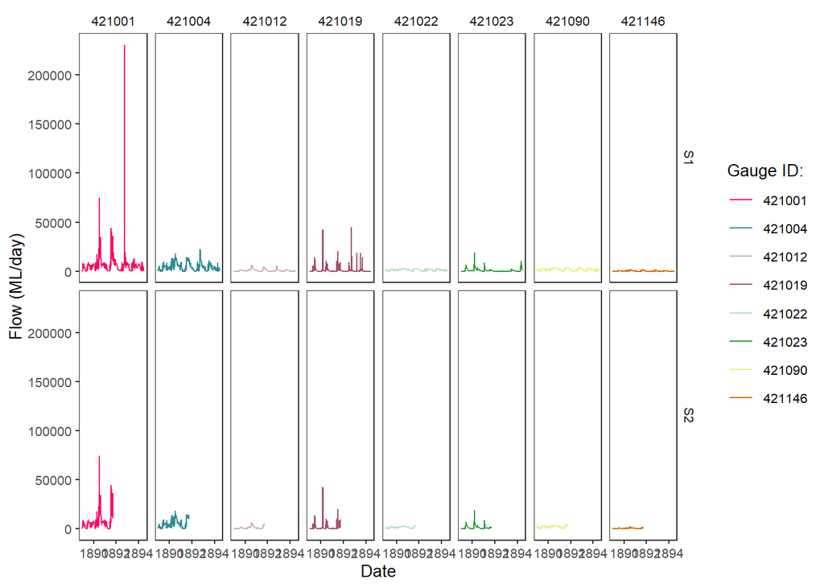

```r
plot_outcomes(nchydros,
  outcome_col = "flow",
  outcome_lab = "Flow (ML/day)",
  x_col = "Date",
  colorset = "gauge",
  color_lab = "Gauge ID:",
  pal_list = "MoMAColors::Warhol",
  facet_row = "scenario",
  facet_col = "gauge",
)
```